# **Spotify Insight**

Lakshya Dugar

Through this report I’ll try to provide a more exhaustive version of the Spotify Wrapped and hopefully some cool insight into the music that you love!

## **General**

You have been using Spotify for - 276 days  
Total time - 73978 minutes (roughly 1233 hours) or about 51 days!  
Unique songs - 3125  
Unique artists - 1182

Heard to for longer than an hour:  
Unique songs - 345  
Unique artists - 143

7% of your songs contain the word “Love”  
19.1% of your songs have been Remastered  
2.9% of your songs are explicit

Your average song is 3:54 seconds long

## **Month Wise**

The playtime is in hours

### 2019

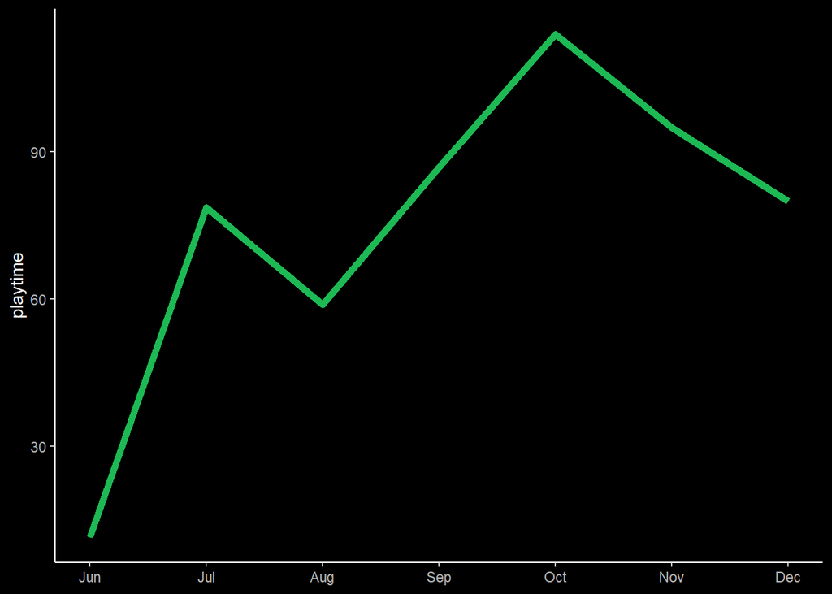

### 2020

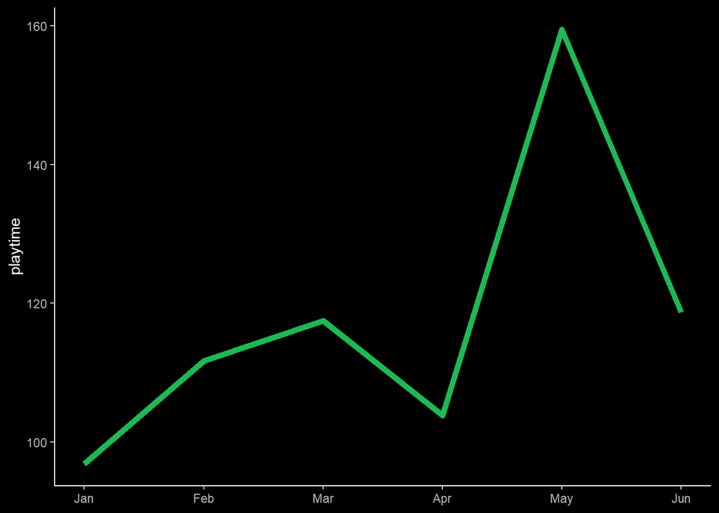

## **Most streamed**

### **Songs**

| no | song | playtime |
| --- | --- | --- |
| 1 | Thunder Road | 32.8 |
| 2 | Comfortably Numb | 14.3 |
| 3 | Like a Rolling Stone | 13.7 |
| 4 | Bridge Over Troubled Water | 11.9 |
| 5 | Someone You Loved | 11.8 |
| 6 | Hey Jude - Remastered 2015 | 9.9 |
| 7 | Mr. Tambourine Man | 9.4 |
| 8 | Piano Man | 9.1 |
| 9 | Let It Be - Remastered 2009 | 8.1 |
| 10 | A Hard Rain’s A-Gonna Fall | 7.5 |
| 11 | Don’t Stop Believin’ | 7.5 |
| 12 | Born to Run | 7.4 |
| 13 | Hey Jude - Remastered 2009 | 7.4 |
| 14 | Drops of Jupiter (Tell Me) | 6.6 |
| 15 | The Winner Takes It All | 6.6 |
| 16 | 18th Floor Balcony | 6.4 |
| 17 | Before You Go | 6.3 |
| 18 | Wonderful Tonight | 6.3 |
| 19 | Love In The Dark | 6.2 |
| 20 | Dancing In the Dark | 6.1 |
| 21 | Imagine - 2010 Mix | 6.1 |
| 22 | American Pie | 5.9 |
| 23 | Vienna | 5.9 |
| 24 | Hurt | 5.6 |
| 25 | Here Comes The Sun - Remastered 2009 | 5.4 |

### **Artists**

| no | artist | playtime |
| --- | --- | --- |
| 1 | The Beatles | 161.4 |
| 2 | Bruce Springsteen | 95.9 |
| 3 | Bob Dylan | 63.2 |
| 4 | Billy Joel | 53.3 |
| 5 | Michael Jackson | 40.7 |
| 6 | ABBA | 40.4 |
| 7 | Adele | 39.1 |
| 8 | Lewis Capaldi | 37.5 |
| 9 | Frank Sinatra | 34.9 |
| 10 | Elton John | 29.8 |
| 11 | Simon & Garfunkel | 25.9 |
| 12 | Stevie Wonder | 24.8 |
| 13 | Elvis Presley | 17.4 |
| 14 | Bryan Adams | 16.9 |
| 15 | Pink Floyd | 15.5 |
| 16 | The Weeknd | 11.5 |
| 17 | Train | 10.8 |
| 18 | Taylor Swift | 10.6 |
| 19 | Queen | 9.1 |
| 20 | Harry Belafonte | 9.0 |
| 21 | Journey | 8.3 |
| 22 | Don McLean | 7.6 |
| 23 | Shawn Mendes | 7.6 |
| 24 | Johnny Cash | 7.3 |
| 25 | Bee Gees | 7.2 |

## **Top Song Trends**

### **2019**

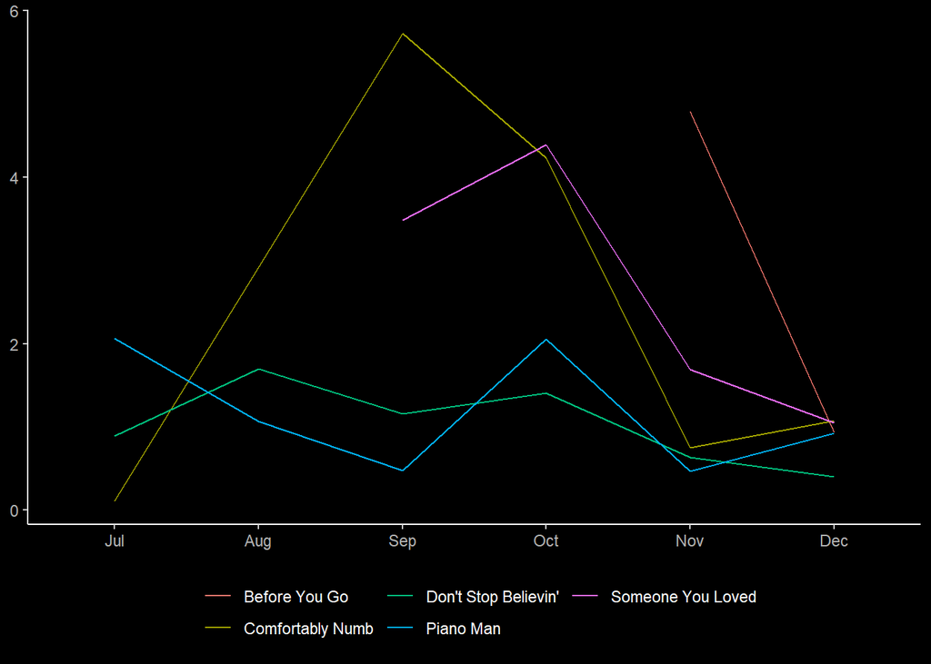

### **2020**

[figure not shown]

## **Top Artist Trends**

### **2019**

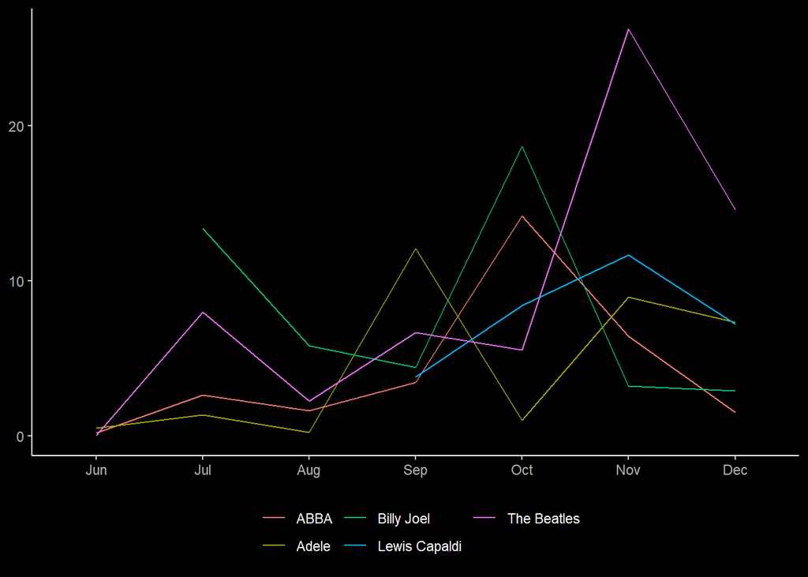

### **2020**

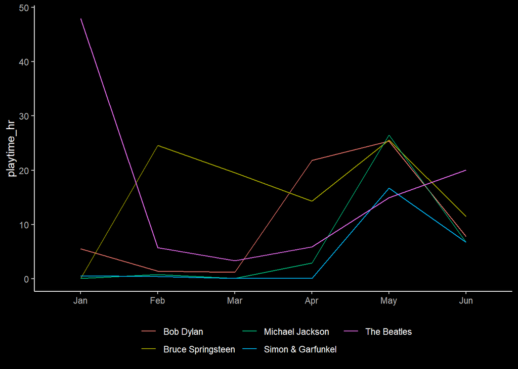

## **The ones that got away**

### Old Songs

| Songs you haven’t gone back to in a long time: |
| --- |
| Before You Go |
| Vienna |
| Dancing Queen |
| Goodnight Saigon |
| Scenes from an Italian Restaurant |
| Fly Me To The Moon (In Other Words) |
| Candy Shop |
| Uptown Girl |
| Everybody Hurts |
| We Didn’t Start the Fire |
| Hallelujah |

### Old Artists

| Artists you haven’t gone back to in a long time: |
| --- |
| Elvis Presley |
| Pink Floyd |
| Taylor Swift |
| Train |
| Journey |
| Lionel Richie |
| Queen |

### New Artists

| Artists you started following in 2020: |
| --- |
| Bruce Springsteen |
| Bob Dylan |
| Michael Jackson |
| Simon & Garfunkel |
| Stevie Wonder |
| The Weeknd |
| Johnny Cash |
| A.R. Rahman |
| Bee Gees |
| Pritam |
| FINNEAS |

### Skipped

The songs that you’ve skipped the most are:

| song | skips |
| --- | --- |
| Don’t Stop Believin’ | 47 |
| Here Comes The Sun - Remastered 2009 | 47 |
| Someone You Loved | 47 |
| Piano Man | 41 |
| Uptown Girl | 39 |
| Hey Jude - Remastered 2015 | 34 |
| Thunder Road | 34 |
| Let It Be - Remastered 2009 | 33 |
| Come Fly With Me - Remastered | 32 |
| Let Her Go | 32 |
| Imagine - 2010 Mix | 30 |
| Comfortably Numb | 29 |
| Like a Rolling Stone | 29 |
| Bohemian Rhapsody - 2011 Mix | 28 |
| Don’t Go Breaking My Heart | 27 |

## **Daily Trend**

**Since:**

### The start

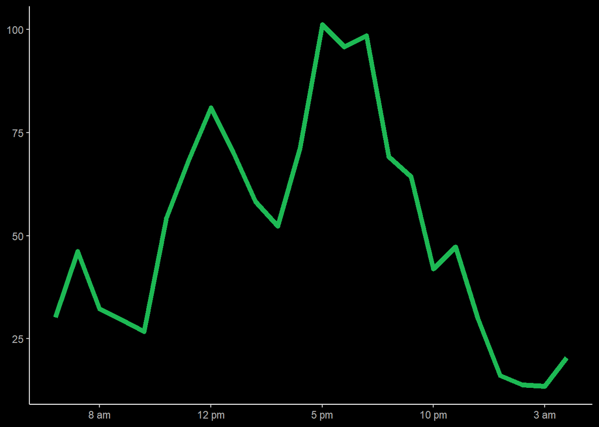

### Lockdown

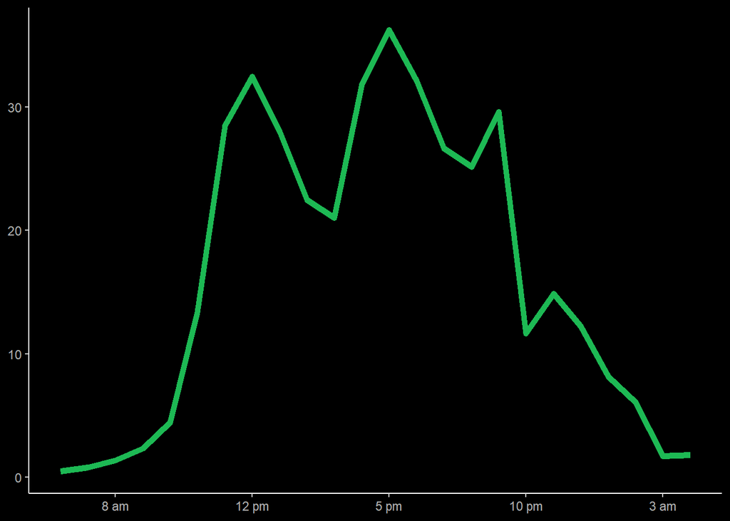

## **Your Library**

Your library is a list of all the songs that you have liked. These are the numbers of that.

### Artists

**Artists whose songs you have liked the most**  
(This might be quite similar to your most streamed artists list)

| no | artist | appearances |
| --- | --- | --- |
| 1 | The Beatles | 71 |
| 2 | Elton John | 32 |
| 3 | ABBA | 31 |
| 4 | Lewis Capaldi | 22 |
| 5 | Bob Dylan | 21 |
| 6 | 5 Seconds of Summer | 19 |
| 7 | Billy Joel | 19 |
| 8 | Frank Sinatra | 19 |
| 9 | Michael Jackson | 18 |
| 10 | Adele | 15 |

### Albums

**Albums containing songs you have liked the most**

| no | album | appearances |
| --- | --- | --- |
| 1 | Divinely Uninspired To A Hellish Extent | 19 |
| 2 | Youngblood | 17 |
| 3 | Staying at Tamara’s | 10 |
| 4 | Goodbye Yellow Brick Road | 7 |
| 5 | 25 | 6 |
| 6 | ABBA Gold | 6 |
| 7 | Help! | 6 |
| 8 | I met you when I was 18. (the playlist) | 6 |
| 9 | Magical Mystery Tour | 6 |
| 10 | Please Please Me | 6 |

### Years

**Your top years of release are**

| year | appearances |
| --- | --- |
| 2017 | 39 |
| 1973 | 36 |
| 2018 | 35 |
| 2019 | 34 |
| 2015 | 24 |
| 1985 | 21 |
| 2008 | 20 |
| 2016 | 20 |
| 1967 | 19 |
| 1971 | 19 |

### Decades

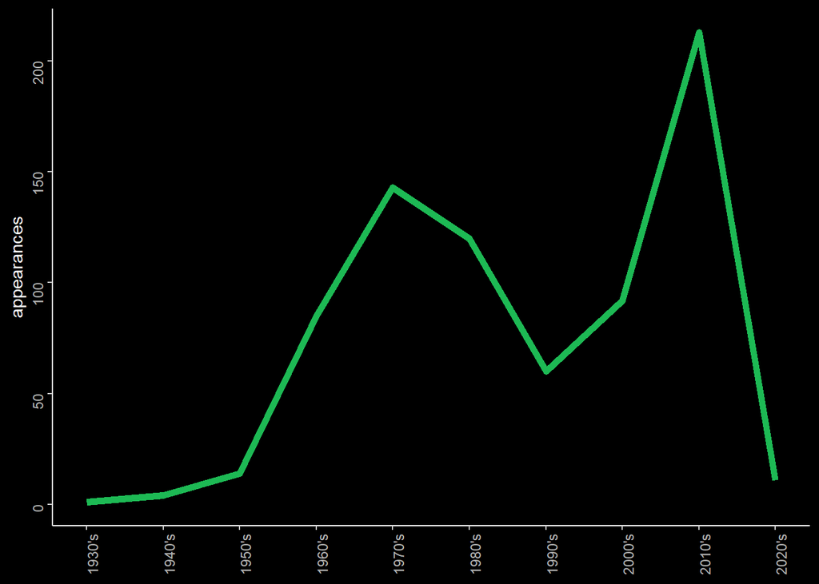

## **Playlists**

### **Dance Party!**

| song | artist |
| --- | --- |
| Billie Jean | Michael Jackson |
| HUMBLE. | Kendrick Lamar |
| P.Y.T. (Pretty Young Thing) | Michael Jackson |
| Killshot | Eminem |
| King Kunta | Kendrick Lamar |
| Don’t Stop ’Til You Get Enough - Single Version | Michael Jackson |
| The Way You Make Me Feel - 2012 Remaster | Michael Jackson |
| I’m Not Alright | Loud Luxury |
| U Can’t Touch This | MC Hammer |
| Somebody That I Used To Know | Gotye |
| I Walk the Line | Johnny Cash |
| Smooth Criminal - 2012 Remaster | Michael Jackson |
| Leave Me Alone - 2012 Remaster | Michael Jackson |
| Sucker | Jonas Brothers |
| SICKO MODE | Travis Scott |
| Chand Sifarish | Shaan |
| Every Breath You Take | The Police |
| Eye of the Tiger | Survivor |
| Respect | Aretha Franklin |
| Ob-La-Di, Ob-La-Da - Remastered 2009 | The Beatles |
| Banana Pancakes | Jack Johnson |
| When I Grow Up | NF |
| 3 Nights | Dominic Fike |
| Three Little Birds | Bob Marley & The Wailers |
| Man in the Mirror - 2012 Remaster | Michael Jackson |
| Rock with You - Single Version | Michael Jackson |
| Giant (with Rag’n’Bone Man) | Calvin Harris |
| Daydreamer | Adele |

### **Workout Beats**

| song | artist |
| --- | --- |
| Smooth Criminal - 2012 Remaster | Michael Jackson |
| Don’t Go Breaking My Heart | Elton John |
| Panama - 2015 Remaster | Van Halen |
| Any Way You Want It | Journey |
| Larger Than Life | Backstreet Boys |
| Back In The U.S.S.R. - Remastered 2009 | The Beatles |
| We Didn’t Start the Fire | Billy Joel |
| Glory Days | Bruce Springsteen |
| Leave Me Alone - 2012 Remaster | Michael Jackson |
| Born in the U.S.A. | Bruce Springsteen |
| You May Be Right | Billy Joel |
| Waterloo | ABBA |
| Born to Run | Bruce Springsteen |
| Uptown Girl | Billy Joel |
| Dancing In the Dark | Bruce Springsteen |
| I’m Still Standing | Elton John |
| When I Kissed The Teacher | ABBA |
| Dancing Queen | ABBA |
| Don’t Stop ’Til You Get Enough - Single Version | Michael Jackson |
| Angeleyes | ABBA |
| Highway to Hell | AC/DC |
| Smells Like Teen Spirit | Nirvana |
| Purple Haze | Jimi Hendrix |
| Footloose - From “Footloose” Soundtrack | Kenny Loggins |
| Best Day Of My Life | American Authors |
| Black or White | Michael Jackson |
| Tell Her About It | Billy Joel |
| Hungry Heart | Bruce Springsteen |
| Wonderwall | Oasis |
| Jump in the Line | Harry Belafonte |
| Bad - 2012 Remaster | Michael Jackson |
| Livin’ On A Prayer | Bon Jovi |
| Thriller | Michael Jackson |
| Giant (with Rag’n’Bone Man) | Calvin Harris |
| Because the Night - Live at Nassau Coliseum, Uniondale, NY - December 1980 | Bruce Springsteen |
| Ring Ring - English Version | ABBA |
| Paradise | George Ezra |
| Movin’ Out (Anthony’s Song) | Billy Joel |
| Pinball Wizard | Elton John |
| Cecilia | Simon & Garfunkel |

### **Life Sucks**

| song | artist |
| --- | --- |
| Hello | Lionel Richie |
| In The Wee Small Hours Of The Morning - Remastered 1998 | Frank Sinatra |
| Say Something | A Great Big World |
| Skyfall | Adele |
| Hallelujah | Jeff Buckley |
| Make You Feel My Love | Adele |
| Sorry Seems To Be The Hardest Word | Elton John |
| Put Your Dreams Away (For Another Day) | Frank Sinatra |
| Secret Garden | Bruce Springsteen |
| With Or Without You | U2 |
| Angel | Sarah McLachlan |
| Lady | Lionel Richie |
| It Was A Very Good Year | Frank Sinatra |
| Right Here Waiting | Richard Marx |
| The Night We Met (feat. Phoebe Bridgers) | Lord Huron |
| Goodnight Saigon | Billy Joel |
| Leaving My Love Behind | Lewis Capaldi |
| If You Are But A Dream (with The Bobby Tucker Singers) | Frank Sinatra |
| After Hours | The Weeknd |
| Love In The Dark | Adele |
| Echoes | Pink Floyd |
| I Won’t Give Up | Jason Mraz |
| Please Forgive Me | Bryan Adams |
| Lighters | Bad Meets Evil |
| This Ain’t A Love Song | Bon Jovi |
| Girl on Fire | Alicia Keys |
| Can You Feel the Love Tonight - End Title/ From “The Lion King”/Soundtrack Version | Elton John |
| Walking The Wire | Imagine Dragons |
| Hurt | Johnny Cash |
| Wild Horses | The Rolling Stones |
| Come Together - Remastered 2009 | The Beatles |
| Youngblood | 5 Seconds of Summer |
| Million Reasons | Lady Gaga |
| I Miss You | Adele |
| Wild Horses - 2009 Mix | The Rolling Stones |
| Good Years | ZAYN |
| Blue Eyes - Remastered 2003 | Elton John |
| Life Of The Party | Shawn Mendes |
| Hold Me While You Wait | Lewis Capaldi |
| Everybody Hurts | R.E.M. |

### **Wake up Happy**

| song | artist |
| --- | --- |
| Glory Days | Bruce Springsteen |
| Ob-La-Di, Ob-La-Da - Remastered 2009 | The Beatles |
| Does Your Mother Know | ABBA |
| Hungry Heart | Bruce Springsteen |
| Ring Ring - English Version | ABBA |
| I Saw Her Standing There - Remastered 2009 | The Beatles |
| Sugar, Sugar | The Archies |
| Johnny B. Goode | Chuck Berry |
| Crocodile Rock | Elton John |
| Rockin’ Robin | Michael Jackson |
| Respect | Aretha Franklin |
| Roll Over Beethoven - Remastered 2009 | The Beatles |
| Angeleyes | ABBA |
| Jack Rabbit - Single Version | Elton John |
| You May Be Right | Billy Joel |
| I’m a Believer - 2006 Remaster | The Monkees |
| Super Trouper | ABBA |
| Part-Time Lover | Stevie Wonder |
| Happy Birthday | Stevie Wonder |
| P.Y.T. (Pretty Young Thing) | Michael Jackson |
| Sir Duke | Stevie Wonder |
| Oh, Pretty Woman | Roy Orbison |
| Cecilia | Simon & Garfunkel |
| Sucker | Jonas Brothers |
| Honky Cat | Elton John |
| Brilliant Disguise | Bruce Springsteen |
| I Want You Back | The Jackson 5 |
| Don’t Stop ’Til You Get Enough - Single Version | Michael Jackson |
| The Bitch Is Back | Elton John |
| Bad Moon Rising | Creedence Clearwater Revival |
| You Make My Dreams (Come True) | Daryl Hall & John Oates |
| Rockin’ Robin | Bobby Day |
| Twist And Shout - Remastered 2009 | The Beatles |
| I Want To Hold Your Hand - Remastered 2009 | The Beatles |
| Only the Lonely | Roy Orbison |
| End Of The Line | Traveling Wilburys |
| Come On Eileen | Dexys Midnight Runners |
| Take A Chance On Me | ABBA |
| Uptight (Everything’s Alright) | Stevie Wonder |
| Centerfold | The J. Geils Band |

### **Relax and Unwind**

| song | artist |
| --- | --- |
| Can’t Help Falling in Love | Haley Reinhart |
| Put Your Dreams Away (For Another Day) | Frank Sinatra |
| Lost Boy | Ruth B. |
| Angel | Sarah McLachlan |
| Nancy (With the Laughing Face) - 78rpm Version | Frank Sinatra |
| Vincent | Don McLean |
| In The Wee Small Hours Of The Morning - Remastered 1998 | Frank Sinatra |
| Blowin’ in the Wind | Bob Dylan |
| Banana Boat (Day-O) | Harry Belafonte |
| All Or Nothing At All | Harry James |
| Daydreamer | Adele |
| Girl from the North Country | Bob Dylan |
| She’s Got a Way - Live at the Paradise, Boston, MA - June 1980 | Billy Joel |
| The Story Never Ends | Lauv |
| Sweet Caroline | Neil Diamond |
| Blackbird - Remastered 2009 | The Beatles |
| I Will Spend My Whole Life Loving You | Imaginary Future |
| More Than Words | Extreme |
| Hallelujah | Jeff Buckley |
| Crazy for You | Adele |
| It Was A Very Good Year | Frank Sinatra |
| Jamaica Farewell - Remastered | Harry Belafonte |
| The Lady Is A Tramp - Remastered | Frank Sinatra |
| Say Something | A Great Big World |
| I Like Me Better - Recorded at Spotify Studios NYC | Lauv |
| Golden Slumbers - Remastered 2009 | The Beatles |
| Hallelujah | Rufus Wainwright |
| Leader of the Band | Dan Fogelberg |
| Yesterday - Remastered 2009 | The Beatles |
| Don’t Worry Be Happy | Bobby McFerrin |
| Dancing On My Own | Calum Scott |
| Lay, Lady, Lay | Bob Dylan |
| Make You Feel My Love | Adele |
| Bang Bang (My Baby Shot Me Down) | Frank Sinatra |
| Can You Feel the Love Tonight - End Title/ From “The Lion King”/Soundtrack Version | Elton John |
| when the party’s over - Recorded at Spotify Studios NYC | Lewis Capaldi |
| Fly Me To The Moon (In Other Words) | Frank Sinatra |
| It’s All over Now, Baby Blue | Bob Dylan |
| Girl Crush - Recorded at Metropolis Studios, London | Harry Styles |
| A Hard Rain’s A-Gonna Fall | Bob Dylan |

### **Pop Pudding**

| song | artist |
| --- | --- |
| Blinding Lights | The Weeknd |
| SICKO MODE | Travis Scott |
| Someone You Loved | Lewis Capaldi |
| Falling | Trevor Daniel |
| Memories | Maroon 5 |
| In Your Eyes | The Weeknd |
| If the World Was Ending - feat. Julia Michaels | JP Saxe |
| lovely (with Khalid) | Billie Eilish |
| Skechers | DripReport |
| hot girl bummer | blackbear |
| Before You Go | Lewis Capaldi |
| 7 rings | Ariana Grande |
| when the party’s over | Billie Eilish |
| Shallow | Lady Gaga |
| Sunflower - Spider-Man: Into the Spider-Verse | Post Malone |
| Level of Concern | Twenty One Pilots |
| Sucker | Jonas Brothers |
| I Like Me Better | Lauv |
| Dancing With A Stranger (with Normani) | Sam Smith |
| Bruises | Lewis Capaldi |
| Lose You To Love Me | Selena Gomez |
| Old Town Road - Remix | Lil Nas X |
| Say You Won’t Let Go | James Arthur |
| Closer | The Chainsmokers |
| Thunder | Imagine Dragons |
| Never Really Over | Katy Perry |
| How Do You Sleep? | Sam Smith |
| changes | XXXTENTACION |
| No Time To Die | Billie Eilish |
| Heartless | The Weeknd |
| After Hours | The Weeknd |
| Moral of the Story | Ashe |
| ME! (feat. Brendon Urie of Panic! At The Disco) | Taylor Swift |
| HUMBLE. | Kendrick Lamar |
| Photograph | Ed Sheeran |
| i’m so tired… | Lauv |
| You Need To Calm Down | Taylor Swift |
| Youngblood | 5 Seconds of Summer |
| Something Just Like This | The Chainsmokers |
| You Are The Reason | Calum Scott |

### **Acoustic Love**

| song | artist |
| --- | --- |
| All Or Nothing At All | Harry James |
| Nancy (With the Laughing Face) - 78rpm Version | Frank Sinatra |
| She’s Got a Way - Live at the Paradise, Boston, MA - June 1980 | Billy Joel |
| Lost Boy | Ruth B. |
| Hometown Glory | Adele |
| Jamaica Farewell - Remastered | Harry Belafonte |
| The Night We Met (feat. Phoebe Bridgers) | Lord Huron |
| Daydreamer | Adele |
| Turning Tables | Adele |
| Skinny Love | Birdy |
| Put Your Dreams Away (For Another Day) | Frank Sinatra |
| Angel | Sarah McLachlan |
| Can’t Help Falling in Love | Haley Reinhart |
| when the party’s over - Recorded at Spotify Studios NYC | Lewis Capaldi |
| Bruises | Lewis Capaldi |
| She’s Leaving Home - Remastered 2009 | The Beatles |
| Can’t Help Falling in Love | Elvis Presley |
| Can’t Help Falling In Love | Elvis Presley |
| Lose My Mind - Acoustic | Dean Lewis |
| Eleanor Rigby - Remastered 2009 | The Beatles |
| Hallelujah | Jeff Buckley |
| There Stands The Glass | Webb Pierce |
| All of Me | John Legend |
| Bridge Over Troubled Water | Johnny Cash |
| If You Are But A Dream (with The Bobby Tucker Singers) | Frank Sinatra |
| A Hard Rain’s A-Gonna Fall | Bob Dylan |
| Crazy for You | Adele |
| Blowin’ in the Wind | Bob Dylan |
| The Story Never Ends | Lauv |
| Vincent | Don McLean |
| Imagine - 2010 Mix | John Lennon |
| The Times They Are A-Changin’ | Bob Dylan |
| golden thing | Cody Simpson |
| Don’t Think Twice, It’s All Right | Bob Dylan |
| Make You Feel My Love | Adele |
| Someone Like You | Adele |
| Mr. Tambourine Man | Bob Dylan |
| Lost On You | Lewis Capaldi |
| I Will Spend My Whole Life Loving You | Imaginary Future |
| Banana Boat (Day-O) | Harry Belafonte |

### **Electronic Focus**

| song | artist |
| --- | --- |
| Smells Like Teen Spirit | Nirvana |
| Miss Missing You | Fall Out Boy |
| With Or Without You | U2 |
| HUMBLE. | Kendrick Lamar |
| Any Way You Want It | Journey |
| Born in the U.S.A. | Bruce Springsteen |
| Voices (Randy Orton) [feat. Rev Theory] | WWE |
| Wonderwall - Remastered | Oasis |
| Helter Skelter - Remastered 2009 | The Beatles |
| Heroes - 2017 Remaster | David Bowie |
| Wonderwall | Oasis |
| King’s Dead (with Kendrick Lamar, Future & James Blake) | Jay Rock |
| Panama - 2015 Remaster | Van Halen |
| Blinding Lights | The Weeknd |
| Carry on Wayward Son | Kansas |
| Can We Dance | The Vamps |
| Yellow | Coldplay |
| Human Touch | Bruce Springsteen |
| All Along the Watchtower | Jimi Hendrix |
| New Rules | Dua Lipa |
| Unconditionally | Katy Perry |
| Just My Type | The Vamps |
| Centuries | Fall Out Boy |
| Wake Me Up | Avicii |
| Set Fire to the Rain | Adele |
| All Night | The Vamps |
| Happy Birthday | Stevie Wonder |
| DNA. | Kendrick Lamar |
| U Can’t Touch This | MC Hammer |
| Bad - 2012 Remaster | Michael Jackson |
| Born to Run | Bruce Springsteen |
| SICKO MODE | Travis Scott |
| Human Touch - Single Edit | Bruce Springsteen |
| Hotel California - 2013 Remaster | Eagles |
| King Kunta | Kendrick Lamar |
| Something Big | Shawn Mendes |
| Purple Haze | Jimi Hendrix |
| Want You Back | 5 Seconds of Summer |
| Shut Up and Dance | WALK THE MOON |
| Once In a While | Timeflies |

## **Bit of nostalgia**

### The start

**The first ten songs you played on Spotify were:**

| song | artist |
| --- | --- |
| Because Of You | 98º |
| Say You Won’t Let Go | James Arthur |
| Waiting For Love | Avicii |
| Lie To Me (feat. Julia Michaels) | 5 Seconds of Summer |
| Nothing Breaks Like a Heart (feat. Miley Cyrus) | Mark Ronson |
| Hey, Soul Sister | Train |
| From the Ground Up | Travis Atreo |
| Fallin’ All In You | Shawn Mendes |
| Personal | The Vamps |
| Please Don’t Go | Joel Adams |

### 2019

**You ended 2019 with:**

| song | artist |
| --- | --- |
| Martha My Dear - Remastered 2009 | The Beatles |
| Why Don’t We Do It In The Road? - Remastered 2009 | The Beatles |
| While My Guitar Gently Weeps - Remastered 2009 | The Beatles |
| Redemption Song | Bob Marley & The Wailers |
| My Heart Will Go On - Love Theme from “Titanic” | Céline Dion |
| My Heart Will Go On - Love Theme from “Titanic” | Céline Dion |
| My Heart Will Go On - Love Theme from “Titanic” | Céline Dion |
| My Heart Will Go On - Love Theme from “Titanic” | Céline Dion |
| My Heart Will Go On - Love Theme from “Titanic” | Céline Dion |
| My Heart Will Go On - Love Theme from “Titanic” | Céline Dion |
| My Heart Will Go On - Love Theme from “Titanic” | Céline Dion |

From **98º** to **Céline Dion** how much did you grow in just one year?

### 2020

**You started 2020 with:**

| song | artist |
| --- | --- |
| Revolution - Remastered 2009 | The Beatles |
| I Am The Walrus - Remastered 2009 | The Beatles |
| Roll Over Beethoven - Remastered 2009 | The Beatles |
| Lucy In The Sky With Diamonds - Remastered 2009 | The Beatles |
| Things We Said Today - Remastered 2009 | The Beatles |
| And I Love Her - Remastered 2009 | The Beatles |
| Golden Slumbers - Remastered 2009 | The Beatles |
| Getting Better - Remastered 2009 | The Beatles |
| I Want To Hold Your Hand - Remastered 2009 | The Beatles |
| No Reply - Remastered 2009 | The Beatles |

### Overall

**The days you heard the most music were:**

| date | playtime |
| --- | --- |
| 3/Jun/2020 | 10.2 |
| 26/Oct/2019 | 10.2 |
| 27/Feb/2020 | 9.8 |
| 30/May/2020 | 9.8 |
| 22/Sep/2019 | 9.5 |
| 16/May/2020 | 9.2 |
| 9/Jan/2020 | 9.2 |
| 23/Feb/2020 | 9.0 |
| 6/Oct/2019 | 8.9 |
| 8/Jun/2020 | 8.8 |

Anything special about 3/Jun/2020?

### Happiness

The blue line indicates average happiness index of your music.  
The brown line indicates average happiness index of music across the world.

#### 2019

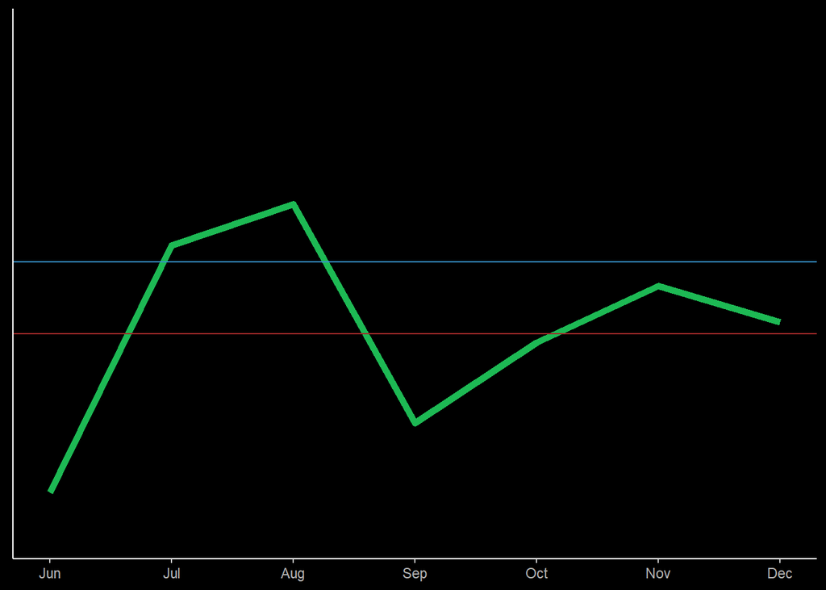

#### 2020

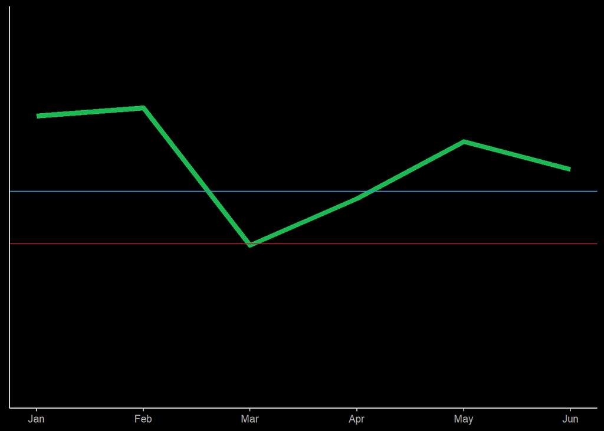

## **Artist Wise**

Your favourite songs by artist:

### **The Beatles**

| no | song | playtime |
| --- | --- | --- |
| 1 | Hey Jude - Remastered 2015 | 9.9 |
| 2 | Let It Be - Remastered 2009 | 8.1 |
| 3 | Hey Jude - Remastered 2009 | 7.4 |
| 4 | Here Comes The Sun - Remastered 2009 | 5.4 |
| 5 | Twist And Shout - Remastered 2009 | 4.3 |
| 6 | Penny Lane - Remastered 2009 | 4.2 |
| 7 | Ob-La-Di, Ob-La-Da - Remastered 2009 | 3.7 |
| 8 | Strawberry Fields Forever - Remastered 2009 | 3.7 |
| 9 | Yesterday - Remastered 2009 | 3.7 |
| 10 | Drive My Car - Remastered 2009 | 3.4 |

### **Bruce Springsteen**

| no | song | playtime |
| --- | --- | --- |
| 1 | Thunder Road | 32.8 |
| 2 | Born to Run | 7.4 |
| 3 | Dancing In the Dark | 6.1 |
| 4 | Brilliant Disguise | 4.7 |
| 5 | Glory Days | 4.4 |
| 6 | Human Touch - Single Edit | 4.2 |
| 7 | The River | 2.9 |
| 8 | Born in the U.S.A. | 2.8 |
| 9 | Hungry Heart | 2.8 |
| 10 | My Hometown | 2.8 |

### **Bob Dylan**

| no | song | playtime |
| --- | --- | --- |
| 1 | Like a Rolling Stone | 13.7 |
| 2 | Mr. Tambourine Man | 9.4 |
| 3 | A Hard Rain’s A-Gonna Fall | 7.4 |
| 4 | Hurricane | 4.8 |
| 5 | Don’t Think Twice, It’s All Right | 2.3 |
| 6 | Murder Most Foul | 2.2 |
| 7 | The Times They Are A-Changin’ | 2.2 |
| 8 | Blowin’ in the Wind | 2.0 |
| 9 | Shelter from the Storm | 2.0 |
| 10 | Girl from the North Country | 1.9 |

### **Billy Joel**

| no | song | playtime |
| --- | --- | --- |
| 1 | Piano Man | 9.1 |
| 2 | Vienna | 5.9 |
| 3 | Goodnight Saigon | 3.9 |
| 4 | Scenes from an Italian Restaurant | 3.8 |
| 5 | Uptown Girl | 3.2 |
| 6 | We Didn’t Start the Fire | 3.1 |
| 7 | New York State of Mind | 2.1 |
| 8 | Just the Way You Are | 1.9 |
| 9 | Only the Good Die Young | 1.9 |
| 10 | She’s Always a Woman | 1.7 |

### **Michael Jackson**

| no | song | playtime |
| --- | --- | --- |
| 1 | Man in the Mirror - 2012 Remaster | 5.2 |
| 2 | Thriller | 4.8 |
| 3 | Billie Jean | 3.4 |
| 4 | Don’t Stop ’Til You Get Enough - Single Version | 3.0 |
| 5 | Smooth Criminal - 2012 Remaster | 3.0 |
| 6 | The Way You Make Me Feel - 2012 Remaster | 2.9 |
| 7 | Beat It - Single Version | 2.8 |
| 8 | Black or White | 2.2 |
| 9 | Rockin’ Robin | 2.2 |
| 10 | Dirty Diana - 2012 Remaster | 2.1 |

### **ABBA**

| no | song | playtime |
| --- | --- | --- |
| 1 | The Winner Takes It All | 6.6 |
| 2 | Dancing Queen | 4.6 |
| 3 | Super Trouper | 3.1 |
| 4 | Does Your Mother Know | 2.7 |
| 5 | Take A Chance On Me | 2.2 |
| 6 | Chiquitita | 1.7 |
| 7 | Mamma Mia | 1.6 |
| 8 | SOS | 1.5 |
| 9 | Lay All Your Love On Me | 1.4 |
| 10 | Voulez-Vous | 1.3 |

### **Adele**

| no | song | playtime |
| --- | --- | --- |
| 1 | Love In The Dark | 6.2 |
| 2 | When We Were Young | 3.1 |
| 3 | Water Under The Bridge | 2.4 |
| 4 | Someone Like You | 2.0 |
| 5 | Set Fire to the Rain | 1.7 |
| 6 | Skyfall | 1.7 |
| 7 | All I Ask | 1.6 |
| 8 | Daydreamer | 1.6 |
| 9 | Make You Feel My Love | 1.6 |
| 10 | I Miss You | 1.5 |

I really hope you liked this insight into the your music!  
Let me know what you think :)